# DA0903_GroupBy slides

```python
%%HTML
<script>
    var code_show=true; //true -> hide code at first

    function code_toggle() {
        $('div.prompt').show(); // always hide prompt
        if (code_show){
            $('div.input').hide();
        } else {
            $('div.input').show();
        }
        code_show = !code_show
    }
    $( document ).ready(code_toggle);
</script>
```

```python
%%HTML
<a href="javascript:code_toggle()">[Toggle Code]</a>
```

[Toggle Code]

```python
from IPython.display import display, HTML

CSS = """
.output {
    flex-direction: row;
}
"""

HTML('<style>{}</style>'.format(CSS))
```

```python
from __future__ import division
from numpy.random import randn
import numpy as np
import os
import matplotlib.pyplot as plt
np.random.seed(12345)
plt.rc('figure', figsize=(10, 6))
from pandas import Series, DataFrame
import pandas as pd
np.set_printoptions(precision=4)
```

# 데이터 수집과 그룹 연산

## 예제: 2012년 연방 선거관리위원회 데이터베이스

미국 연방 선거관리위원회는 정치 활동 후원금에 대한 데이터를 공개했다. 이 데이터에는 기부자의 이름, 직업, 고용 형태, 주소, 기부금액이 포함되어 있다. 그 중 재미있는 데이터는 2012년 미국 대통령 선거 데이터다. http://www.fec.gov/disclosurep/PDownload.do

P00000001-All.csv는 2012년 미국 대통령 선거 데이터이며 2012년 6월 현재 모든 주를 포함하는 전체 데이터는 150메가바이트의 CSV 파일이다.

(P00000001-ALL-2016.csv는 2016년 미국 대통령 선거 데이터이다. )

```python
fec = pd.read_csv('ch09/P00000001-ALL.csv', low_memory=False)
```

```python
fec2016 = pd.read_csv('ch09/P00000001-ALL-2016.csv', low_memory=False)
```

```python
fec.info()
```

```
<class 'pandas.core.frame.DataFrame'>
Int64Index: 991475 entries, 0 to 1001730
Data columns (total 17 columns):
cmte_id              991475 non-null object
cand_id              991475 non-null object
cand_nm              991475 non-null object
contbr_nm            991475 non-null object
contbr_city          991457 non-null object
contbr_st            991471 non-null object
contbr_zip           991373 non-null object
contbr_employer      983833 non-null object
contbr_occupation    989133 non-null object
contb_receipt_amt    991475 non-null float64
contb_receipt_dt     991475 non-null object
receipt_desc         5219 non-null object
memo_cd              89461 non-null object
memo_text            94274 non-null object
form_tp              991475 non-null object
file_num             991475 non-null int64
party                991475 non-null object
dtypes: float64(1), int64(1), object(15)
memory usage: 136.2+ MB
```

```python
fec2016.info()
```

```
<class 'pandas.core.frame.DataFrame'>
Index: 7440252 entries, C00458844 to C00623884
Data columns (total 18 columns):
cmte_id              object
cand_id              object
cand_nm              object
contbr_nm            object
contbr_city          object
contbr_st            object
contbr_zip           object
contbr_employer      object
contbr_occupation    float64
contb_receipt_amt    object
contb_receipt_dt     object
receipt_desc         object
memo_cd              object
memo_text            object
form_tp              int64
file_num             object
tran_id              object
election_tp          float64
dtypes: float64(2), int64(1), object(15)
memory usage: 1.1+ GB
```

```python
fec.iloc[123456]
```

```
cmte_id                                 C00431445
cand_id                                 P80003338
cand_nm                             Obama, Barack
contbr_nm                             KIM, LEEZIE
contbr_city                               PHOENIX
contbr_st                                      AZ
contbr_zip                              850031154
contbr_employer      US DEPT OF HOMELAND SECURITY
contbr_occupation                        ATTORNEY
contb_receipt_amt                             250
contb_receipt_dt                        30-JUN-11
receipt_desc                                  NaN
memo_cd                                       NaN
memo_text                                     NaN
form_tp                                     SA17A
file_num                                   756214
party                                    Democrat
Name: 125611, dtype: object
```

기부자와 선거자금에서 찾을 수 있는 패턴에 대한 통계를 추출하기 위해 이 데이터를 적당한 크기로 쪼개서 나누는 다양한 방법을 찾을 수 있을 것이다.

```python
unique_cands = fec.cand_nm.unique()
unique_cands
```

```
array(['Bachmann, Michelle', 'Romney, Mitt', 'Obama, Barack',
       "Roemer, Charles E. 'Buddy' III", 'Pawlenty, Timothy',
       'Johnson, Gary Earl', 'Paul, Ron', 'Santorum, Rick',
       'Cain, Herman', 'Gingrich, Newt', 'McCotter, Thaddeus G',
       'Huntsman, Jon', 'Perry, Rick'], dtype=object)
```

```python
unique_cands[2]
```

```
'Obama, Barack'
```

소속 정당은 사전을 사용해 표시할 수 있다.

```python
parties = {'Bachmann, Michelle': 'Republican',
           'Cain, Herman': 'Republican',
           'Gingrich, Newt': 'Republican',
           'Huntsman, Jon': 'Republican',
           'Johnson, Gary Earl': 'Republican',
           'McCotter, Thaddeus G': 'Republican',
           'Obama, Barack': 'Democrat',
           'Paul, Ron': 'Republican',
           'Pawlenty, Timothy': 'Republican',
           'Perry, Rick': 'Republican',
           "Roemer, Charles E. 'Buddy' III": 'Republican',
           'Romney, Mitt': 'Republican',
           'Santorum, Rick': 'Republican'}
```

이제 이 사전 정보를 이용해서 Series 객체에 map 매소드를 통해 후보 이름으로부터 정당 배열을 계산해낼 수 있다.

```python
fec.cand_nm[123456:123461]
```

```
125611    Obama, Barack
125612    Obama, Barack
125613    Obama, Barack
125614    Obama, Barack
125615    Obama, Barack
Name: cand_nm, dtype: object
```

```python
fec.cand_nm[123456:123461].map(parties)
```

```
125611    Democrat
125612    Democrat
125613    Democrat
125614    Democrat
125615    Democrat
Name: cand_nm, dtype: object
```

```python
# Add it as a column
fec['party'] = fec.cand_nm.map(parties)
```

```python
fec['party'].value_counts()
```

```
Democrat      589127
Republican    402348
Name: party, dtype: int64
```

contb_receipt_amt 열에서 음수로 표현된 데이터들은 환급금이므로 양수인 데이터만 골라낸다.

```python
(fec.contb_receipt_amt > 0).value_counts()
```

```
True     991475
False     10256
Name: contb_receipt_amt, dtype: int64
```

```python
fec = fec[fec.contb_receipt_amt > 0]
```

버락 오바마와 미트 롬니가 양대 후보이므로 이 두 후보의 기부금 정보만 따로 추려낸다.

```python
fec_mrbo = fec[fec.cand_nm.isin(['Obama, Barack', 'Romney, Mitt'])]
```

### 직업 및 피고용 별 기부 통계

직업에 따른 기부 내역 통계를 구해보자.

```python
fec.contbr_occupation.value_counts()[:10]
```

```
RETIRED         233990
NOT PROVIDED     57151
ATTORNEY         34286
HOMEMAKER        29931
PHYSICIAN        23432
ENGINEER         14334
TEACHER          13990
CONSULTANT       13273
PROFESSOR        12555
NOT EMPLOYED      9828
Name: contbr_occupation, dtype: int64
```

비슷한 직업인데 다른 직업으로 표기되어 있는 데이터가 많이 포함되어 있다. occ_mapping이라는 사전을 이용하여 비슷한 유형을 동일한 직업으로 분류되도록 해보자. 매핑 정보가 없으면 그대로 유지된다.

```python
occ_mapping = {
   'INFORMATION REQUESTED PER BEST EFFORTS' : 'NOT PROVIDED',
   'INFORMATION REQUESTED' : 'NOT PROVIDED',
   'INFORMATION REQUESTED (BEST EFFORTS)' : 'NOT PROVIDED',
   'C.E.O.': 'CEO'
}

# If no mapping provided, return x
f = lambda x: occ_mapping.get(x, x)
fec.contbr_occupation = fec.contbr_occupation.map(f)
```

고용주(contbr_employer) 열도 사전을 이용해 데이터를 정리하자.

```python
emp_mapping = {
   'INFORMATION REQUESTED PER BEST EFFORTS' : 'NOT PROVIDED',
   'INFORMATION REQUESTED' : 'NOT PROVIDED',
   'SELF' : 'SELF-EMPLOYED',
   'SELF EMPLOYED' : 'SELF-EMPLOYED',
}

# If no mapping provided, return x
f = lambda x: emp_mapping.get(x, x)
fec.contbr_employer = fec.contbr_employer.map(f)
```

pivot_table을 사용해서 정당과 직업별로 데이터를 집계한 다음 2백만불 이상 기부한 직업만 골라내자.

```python
by_occupation = fec.pivot_table('contb_receipt_amt',
                                index='contbr_occupation',
                                columns='party', aggfunc='sum')
```

```python
over_2mm = by_occupation[by_occupation.sum(1) > 2000000]
over_2mm
```

| party contbr_occupation | Democrat | Republican |
| --- | --- | --- |
| ATTORNEY | 11141982.97 | 7.477194e+06 |
| CEO | 2074974.79 | 4.211041e+06 |
| CONSULTANT | 2459912.71 | 2.544725e+06 |
| ENGINEER | 951525.55 | 1.818374e+06 |
| EXECUTIVE | 1355161.05 | 4.138850e+06 |
| HOMEMAKER | 4248875.80 | 1.363428e+07 |
| INVESTOR | 884133.00 | 2.431769e+06 |
| LAWYER | 3160478.87 | 3.912243e+05 |
| MANAGER | 762883.22 | 1.444532e+06 |
| NOT PROVIDED | 4866973.96 | 2.056547e+07 |
| OWNER | 1001567.36 | 2.408287e+06 |
| PHYSICIAN | 3735124.94 | 3.594320e+06 |
| PRESIDENT | 1878509.95 | 4.720924e+06 |
| PROFESSOR | 2165071.08 | 2.967027e+05 |
| REAL ESTATE | 528902.09 | 1.625902e+06 |
| RETIRED | 25305116.38 | 2.356124e+07 |
| SELF-EMPLOYED | 672393.40 | 1.640253e+06 |

위 데이터를 수평막대그래프를 이용해 시각화하자.

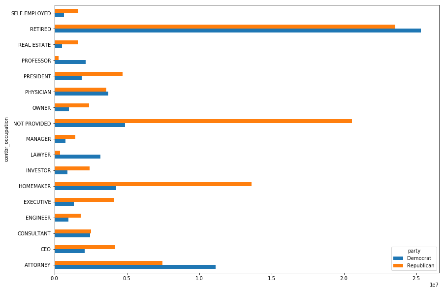

```python
over_2mm.plot(kind='barh', figsize=(14,10))
```

오바마 후보와 롬니 후보별로 가장 많은 금액을 기부한 직군을 알아보자.

```python
def get_top_amounts(group, key, n=5):
    totals = group.groupby(key)['contb_receipt_amt'].sum()

    # totals를 오름차순으로 정렬 후 마지막 n개 슬라이싱
    return totals.sort_values(ascending=False)[:n]
```

```python
grouped = fec_mrbo.groupby('cand_nm')
grouped.apply(get_top_amounts, 'contbr_occupation', n=7)
```

```
cand_nm        contbr_occupation
Obama, Barack  RETIRED              25305116.38
               ATTORNEY             11141982.97
               NOT PROVIDED          4866973.96
               HOMEMAKER             4248875.80
               PHYSICIAN             3735124.94
               LAWYER                3160478.87
               CONSULTANT            2459912.71
Romney, Mitt   RETIRED              11508473.59
               NOT PROVIDED         11396894.84
               HOMEMAKER             8147446.22
               ATTORNEY              5364718.82
               PRESIDENT             2491244.89
               CEO                   2324297.03
               EXECUTIVE             2300947.03
Name: contb_receipt_amt, dtype: float64
```

```python
grouped.apply(get_top_amounts, 'contbr_employer', n=10)
```

```
cand_nm        contbr_employer
Obama, Barack  RETIRED               22694358.85
               SELF-EMPLOYED         18626807.16
               NOT EMPLOYED           8586308.70
               NOT PROVIDED           5053480.37
               HOMEMAKER              2605408.54
               STUDENT                 318831.45
               VOLUNTEER               257104.00
               MICROSOFT               215585.36
               SIDLEY AUSTIN LLP       168254.00
               REFUSED                 149516.07
Romney, Mitt   NOT PROVIDED          12059527.24
               RETIRED               11506225.71
               HOMEMAKER              8147196.22
               SELF-EMPLOYED          7414115.22
               STUDENT                 496490.94
               CREDIT SUISSE           281150.00
               MORGAN STANLEY          267266.00
               GOLDMAN SACH & CO.      238250.00
               BARCLAYS CAPITAL        162750.00
               H.I.G. CAPITAL          139500.00
Name: contb_receipt_amt, dtype: float64
```

### 버킷을 이용한 기부 금액

cut 함수를 사용해서 기부 규모별로 버킷을 만들어 기부자 수를 분할해보자.

```python
bins = np.array([0, 1, 10, 100, 1000, 10000, 100000, 1000000, 10000000])
labels = pd.cut(fec_mrbo.contb_receipt_amt, bins)
labels
```

```
411           (10, 100]
412         (100, 1000]
413         (100, 1000]
414           (10, 100]
415           (10, 100]
416           (10, 100]
417         (100, 1000]
418           (10, 100]
419         (100, 1000]
420           (10, 100]
421           (10, 100]
422         (100, 1000]
423         (100, 1000]
424         (100, 1000]
425         (100, 1000]
```

[output cut: 48 more lines]

후보자 이름과 버킷으로 분할해 놓은 labels를 기준으로 그룹핑을 하고 기부 금액에 따른 히스토그램을 그릴 수 있다.

```python
grouped = fec_mrbo.groupby(['cand_nm', labels])
grouped.size().unstack(0)
```

| cand_nm contb_receipt_amt | Obama, Barack | Romney, Mitt |
| --- | --- | --- |
| (0, 1] | 493.0 | 77.0 |
| (1, 10] | 40070.0 | 3681.0 |
| (10, 100] | 372280.0 | 31853.0 |
| (100, 1000] | 153991.0 | 43357.0 |
| (1000, 10000] | 22284.0 | 26186.0 |
| (10000, 100000] | 2.0 | 1.0 |
| (100000, 1000000] | 3.0 | NaN |
| (1000000, 10000000] | 4.0 | NaN |

```python
grouped.size()
```

```
cand_nm        contb_receipt_amt
Obama, Barack  (0, 1]                    493
               (1, 10]                 40070
               (10, 100]              372280
               (100, 1000]            153991
               (1000, 10000]           22284
               (10000, 100000]             2
               (100000, 1000000]           3
               (1000000, 10000000]         4
Romney, Mitt   (0, 1]                     77
               (1, 10]                  3681
               (10, 100]               31853
               (100, 1000]             43357
               (1000, 10000]           26186
               (10000, 100000]             1
dtype: int64
```

이 데이터를 보면 오바마는 롬니보다 적은 금액의 기부를 훨씬 많이 받았다. 기부금액을 모두 더한 후 버킷별로 정규화해서 후보별 전체 기부금액 대비 비율을 시각화해보자.

```python
bucket_sums = grouped.contb_receipt_amt.sum().unstack(0)
bucket_sums
```

| cand_nm contb_receipt_amt | Obama, Barack | Romney, Mitt |
| --- | --- | --- |
| (0, 1] | 318.24 | 77.00 |
| (1, 10] | 337267.62 | 29819.66 |
| (10, 100] | 20288981.41 | 1987783.76 |
| (100, 1000] | 54798531.46 | 22363381.69 |
| (1000, 10000] | 51753705.67 | 63942145.42 |
| (10000, 100000] | 59100.00 | 12700.00 |
| (100000, 1000000] | 1490683.08 | NaN |
| (1000000, 10000000] | 7148839.76 | NaN |

```python
normed_sums = bucket_sums.div(bucket_sums.sum(axis=1), axis=0)
normed_sums
```

| cand_nm contb_receipt_amt | Obama, Barack | Romney, Mitt |
| --- | --- | --- |
| (0, 1] | 0.805182 | 0.194818 |
| (1, 10] | 0.918767 | 0.081233 |
| (10, 100] | 0.910769 | 0.089231 |
| (100, 1000] | 0.710176 | 0.289824 |
| (1000, 10000] | 0.447326 | 0.552674 |
| (10000, 100000] | 0.823120 | 0.176880 |
| (100000, 1000000] | 1.000000 | NaN |
| (1000000, 10000000] | 1.000000 | NaN |

```python
bucket_sums
```

| cand_nm contb_receipt_amt | Obama, Barack | Romney, Mitt |
| --- | --- | --- |
| (0, 1] | 318.24 | 77.00 |
| (1, 10] | 337267.62 | 29819.66 |
| (10, 100] | 20288981.41 | 1987783.76 |
| (100, 1000] | 54798531.46 | 22363381.69 |
| (1000, 10000] | 51753705.67 | 63942145.42 |
| (10000, 100000] | 59100.00 | 12700.00 |
| (100000, 1000000] | 1490683.08 | NaN |
| (1000000, 10000000] | 7148839.76 | NaN |

기부금액 순에서 가장 높은 2개의 버킷은 한 후보(오바마)에게만 존재하므로 그래프에서 제외하고 나머지 결과를 시각화하면 아래와 같다.

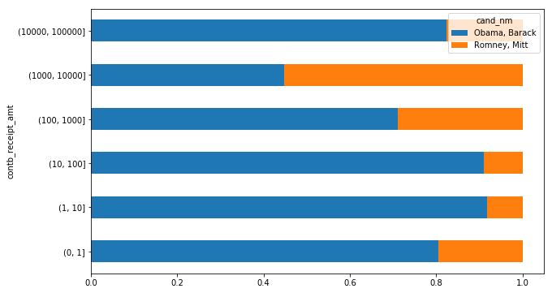

```python
normed_sums[:-2].plot(kind='barh', stacked=True)
```

### 주 별 기부 통계

데이터를 후보자와 주 별로 집계해보자.

```python
grouped = fec_mrbo.groupby(['cand_nm', 'contbr_st'])
totals = grouped.contb_receipt_amt.sum().unstack(0).fillna(0)
totals = totals[totals.sum(1) > 100000]
totals[:10]
```

| cand_nm contbr_st | Obama, Barack | Romney, Mitt |
| --- | --- | --- |
| AK | 281840.15 | 86204.24 |
| AL | 543123.48 | 527303.51 |
| AR | 359247.28 | 105556.00 |
| AZ | 1506476.98 | 1888436.23 |
| CA | 23824984.24 | 11237636.60 |
| CO | 2132429.49 | 1506714.12 |
| CT | 2068291.26 | 3499475.45 |
| DC | 4373538.80 | 1025137.50 |
| DE | 336669.14 | 82712.00 |
| FL | 7318178.58 | 8338458.81 |

totals/totals.sum(1)을 수행하면 각 후보에 대해 주 별로 전체 기부금액 대비 상대적인 비율을 얻을 수 있다.

```python
percent = totals.div(totals.sum(1), axis=0)
percent[:10]
```

| cand_nm contbr_st | Obama, Barack | Romney, Mitt |
| --- | --- | --- |
| AK | 0.765778 | 0.234222 |
| AL | 0.507390 | 0.492610 |
| AR | 0.772902 | 0.227098 |
| AZ | 0.443745 | 0.556255 |
| CA | 0.679498 | 0.320502 |
| CO | 0.585970 | 0.414030 |
| CT | 0.371476 | 0.628524 |
| DC | 0.810113 | 0.189887 |
| DE | 0.802776 | 0.197224 |
| FL | 0.467417 | 0.532583 |

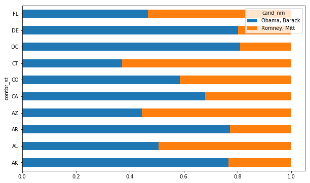

```python
percent[:10].plot(kind='barh', stacked=True)
```